# STAT 4310 Final Project: Beauty data

Group F: Elizabeth Bekele, Neha Gyawali, Alison Cheek

# Introduction

The name of our data is beauty and it comes from the wooldridge package. The data has 1260 observations/rows and 17 variables. In summary the variables include qualities of an employee. Some of the variables include: if they are female, black, married, living in the city, years of experience and education, the hourly wage, and a rating on their appearance. For an in-depth list of the variables look below:

| Variable Name | Meaning |
| --- | --- |
| wage | hourly wage |
| lwage | log(wage) |
| belavg | 1 if looks <= 2 |
| abvavg | 1 if looks >= 4 |
| exper | years of work experience |
| looks | from 1-5 |
| union | 1 if union member |
| goodhlth | 1 if good health |
| black | 1 if black |
| female | 1 if female |
| married | 1 if married |
| south | 1 if live in south |
| bigcity | 1 if lives in big city |
| smllcity | 1 if lives in small city |
| service | 1 if in service industry |
| expersq | exper^2 |
| educ | years of schooling |

# Data Exploration

|  | wage | lwage | belavg | abvavg | exper | looks | union | goodhlth | black | female | married | south | bigcity | smllcity | service | expersq | educ |
| --- | --- | --- | --- | --- | --- | --- | --- | --- | --- | --- | --- | --- | --- | --- | --- | --- | --- |
| 1 | 5.73 | 1.745715 | 0 | 1 | 30 | 4 | 0 | 1 | 0 | 1 | 1 | 0 | 0 | 1 | 1 | 900 | 14 |
| 2 | 4.28 | 1.453953 | 0 | 0 | 28 | 3 | 0 | 1 | 0 | 1 | 1 | 1 | 0 | 1 | 0 | 784 | 12 |
| 3 | 7.96 | 2.074429 | 0 | 1 | 35 | 4 | 0 | 1 | 0 | 1 | 0 | 0 | 0 | 1 | 0 | 1225 | 10 |
| 4 | 11.57 | 2.448416 | 0 | 0 | 38 | 3 | 0 | 1 | 0 | 0 | 1 | 0 | 1 | 0 | 1 | 1444 | 16 |
| 5 | 11.42 | 2.435366 | 0 | 0 | 27 | 3 | 0 | 1 | 0 | 0 | 1 | 0 | 0 | 1 | 0 | 729 | 16 |
| 6 | 3.91 | 1.363537 | 0 | 0 | 20 | 3 | 0 | 0 | 0 | 1 | 1 | 0 | 1 | 0 | 0 | 400 | 12 |

```r
#Check if there are NA's
sum(is.na(beauty))
```

```
## [1] 0
```

```r
#Check data type of each variable
str(beauty)
```

```
## 'data.frame':    1260 obs. of  17 variables:
##  $ wage    : num  5.73 4.28 7.96 11.57 11.42 ...
##  $ lwage   : num  1.75 1.45 2.07 2.45 2.44 ...
##  $ belavg  : int  0 0 0 0 0 0 0 0 0 0 ...
##  $ abvavg  : int  1 0 1 0 0 0 0 1 0 0 ...
##  $ exper   : int  30 28 35 38 27 20 12 5 5 12 ...
##  $ looks   : int  4 3 4 3 3 3 3 4 3 3 ...
##  $ union   : int  0 0 0 0 0 0 0 1 0 0 ...
##  $ goodhlth: int  1 1 1 1 1 0 1 1 1 1 ...
##  $ black   : int  0 0 0 0 0 0 0 0 0 0 ...
##  $ female  : int  1 1 1 0 0 1 0 0 1 1 ...
##  $ married : int  1 1 0 1 1 1 1 0 0 0 ...
##  $ south   : int  0 1 0 0 0 0 0 0 0 0 ...
##  $ bigcity : int  0 0 0 1 0 1 1 0 0 0 ...
##  $ smllcity: int  1 1 1 0 1 0 0 1 0 1 ...
##  $ service : int  1 0 0 1 0 0 0 0 0 0 ...
##  $ expersq : int  900 784 1225 1444 729 400 144 25 25 144 ...
##  $ educ    : int  14 12 10 16 16 12 16 16 16 12 ...
##  - attr(*, "time.stamp")= chr "25 Jun 2011 23:03"
```

Factors that are currently integers:

- belavg (1 if looks <= 2)
- abavag (1 if looks >= 4)
- union
- goodhlth
- black
- female
- married
- south
- bigcity
- smllcity
- service
- looks (from 1 - 5)

| looks_1 | looks_2 | looks_3 | looks_4 | looks_5 |
| --- | --- | --- | --- | --- |
| 0 | 0 | 0 | 1 | 0 |
| 0 | 0 | 1 | 0 | 0 |
| 0 | 0 | 0 | 1 | 0 |
| 0 | 0 | 1 | 0 | 0 |
| 0 | 0 | 1 | 0 | 0 |
| 0 | 0 | 1 | 0 | 0 |

```
## Classes 'data.table' and 'data.frame':   1260 obs. of  21 variables:
##  $ wage    : num  5.73 4.28 7.96 11.57 11.42 ...
##  $ lwage   : num  1.75 1.45 2.07 2.45 2.44 ...
##  $ belavg  : Factor w/ 2 levels "0","1": 1 1 1 1 1 1 1 1 1 1 ...
##  $ abvavg  : Factor w/ 2 levels "0","1": 2 1 2 1 1 1 1 2 1 1 ...
##  $ exper   : int  30 28 35 38 27 20 12 5 5 12 ...
##  $ looks_1 : Factor w/ 2 levels "0","1": 1 1 1 1 1 1 1 1 1 1 ...
##  $ looks_2 : Factor w/ 2 levels "0","1": 1 1 1 1 1 1 1 1 1 1 ...
##  $ looks_3 : Factor w/ 2 levels "0","1": 1 2 1 2 2 2 2 1 2 2 ...
##  $ looks_4 : Factor w/ 2 levels "0","1": 2 1 2 1 1 1 1 2 1 1 ...
##  $ looks_5 : Factor w/ 2 levels "0","1": 1 1 1 1 1 1 1 1 1 1 ...
##  $ union   : Factor w/ 2 levels "0","1": 1 1 1 1 1 1 1 2 1 1 ...
##  $ goodhlth: Factor w/ 2 levels "0","1": 2 2 2 2 2 1 2 2 2 2 ...
##  $ black   : Factor w/ 2 levels "0","1": 1 1 1 1 1 1 1 1 1 1 ...
##  $ female  : Factor w/ 2 levels "0","1": 2 2 2 1 1 2 1 1 2 2 ...
##  $ married : Factor w/ 2 levels "0","1": 2 2 1 2 2 2 2 1 1 1 ...
##  $ south   : Factor w/ 2 levels "0","1": 1 2 1 1 1 1 1 1 1 1 ...
##  $ bigcity : Factor w/ 2 levels "0","1": 1 1 1 2 1 2 2 1 1 1 ...
##  $ smllcity: Factor w/ 2 levels "0","1": 2 2 2 1 2 1 1 2 1 2 ...
##  $ service : Factor w/ 2 levels "0","1": 2 1 1 2 1 1 1 1 1 1 ...
##  $ expersq : int  900 784 1225 1444 729 400 144 25 25 144 ...
##  $ educ    : int  14 12 10 16 16 12 16 16 16 12 ...
##  - attr(*, ".internal.selfref")=<externalptr>
```

# Simple Linear Regression Model

## Model 1

To start off, we will make a linear regression model excluding predictors that are calculated based on other predictors. We are removing expersq, lwage, and the 5 columns of looks because we are keeping exper, wage, belavg, and abvag.

The response we are interested in is wage. We want to know if certain predictors can determine an employee’s hourly wage.

```r
attach(beauty)

mod.all <- lm(wage ~. -expersq -lwage -looks_1 -looks_2 -looks_3 -looks_4 -looks_5, beauty)
summary(mod.all)
```

```
##
## Call:
## lm(formula = wage ~ . - expersq - lwage - looks_1 - looks_2 -
##     looks_3 - looks_4 - looks_5, data = beauty)
##
## Residuals:
##    Min     1Q Median     3Q    Max
## -6.541 -2.133 -0.541  1.186 71.907
##
## Coefficients:
##             Estimate Std. Error t value Pr(>|t|)
## (Intercept) -0.94468    0.85395  -1.106  0.26883
## belavg1     -0.77351    0.36973  -2.092  0.03663 *
## abvavg1      0.17226    0.26768   0.644  0.52000
## exper        0.07765    0.01068   7.271 6.30e-13 ***
## union1       0.58565    0.26792   2.186  0.02901 *
## goodhlth1   -0.02245    0.47593  -0.047  0.96238
## black1      -0.13452    0.46191  -0.291  0.77093
## female1     -2.12282    0.27652  -7.677 3.28e-14 ***
## married1     0.80987    0.27454   2.950  0.00324 **
## south1       0.37575    0.31211   1.204  0.22886
## bigcity1     1.70265    0.33668   5.057 4.89e-07 ***
## smllcity1    0.55932    0.27445   2.038  0.04176 *
## service1    -0.47562    0.28837  -1.649  0.09933 .
## educ         0.42641    0.05007   8.516  < 2e-16 ***
## ---
## Signif. codes:  0 '***' 0.001 '**' 0.01 '*' 0.05 '.' 0.1 ' ' 1
##
## Residual standard error: 4.138 on 1246 degrees of freedom
## Multiple R-squared:  0.2199, Adjusted R-squared:  0.2118
## F-statistic: 27.02 on 13 and 1246 DF,  p-value: < 2.2e-16
```

The starting $R^2$ is 21.99% and the residual standard error, $s$, 4.138.

The low $R^2$ is due to extra predictors that are not significant in explaining the hourly wage of an employee. Predictors we want to remove include: abvavg, goodhlth, black, south, and service. These predictors have p-values that are above 0.05 and do not contribute significantly to explaining the model.

## Residual Assumptions

**1) Normally Distributed**

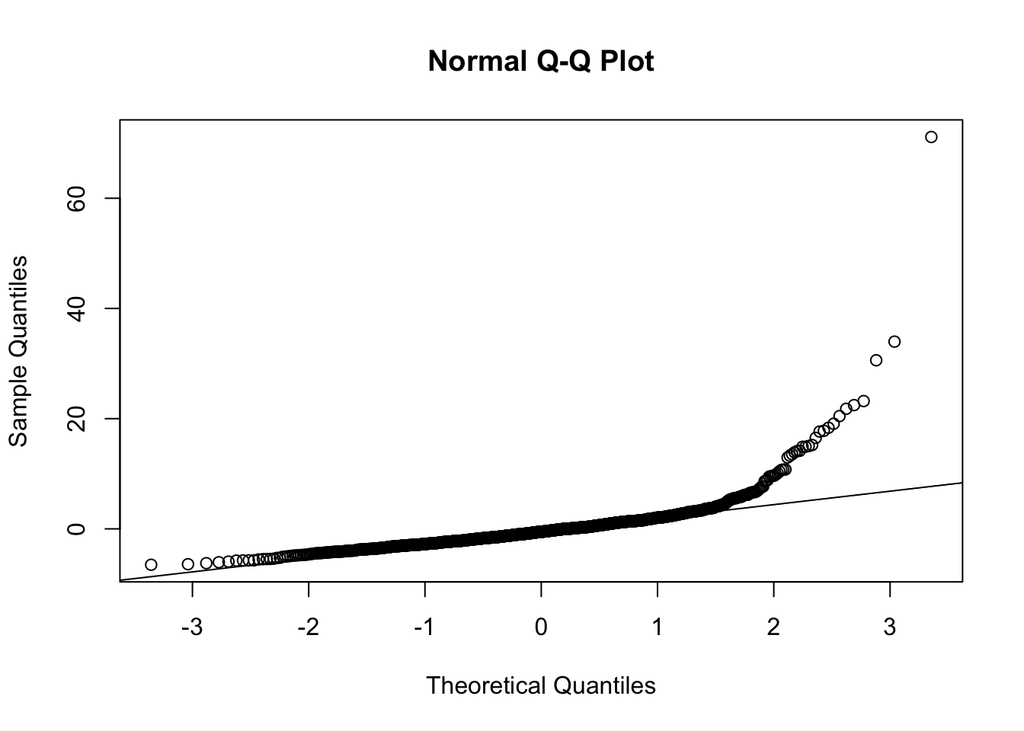

```r
qqnorm(residuals)
qqline(residuals)
```

```r
shapiro.test(residuals)
```

```
##
##  Shapiro-Wilk normality test
##
## data:  residuals
## W = 0.64748, p-value < 2.2e-16
```

**2) Checking for Zero Mean and Constant Variance**

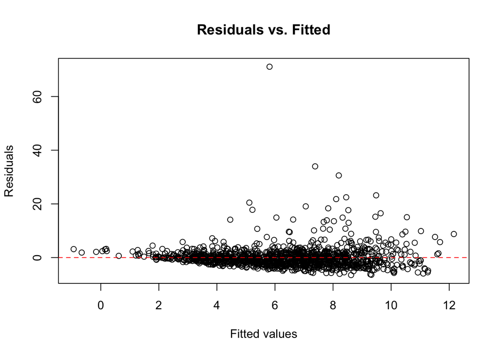

```r
plot(mod.all$fitted.values, residuals,
xlab = "Fitted values",
ylab = "Residuals",
main = "Residuals vs. Fitted")
abline(h = 0, lty = 2, col = "red")
```

**BP-Test for heteroskedasticity**

```r
library(lmtest)
bptest(mod.all)
```

```
##
##  studentized Breusch-Pagan test
##
## data:  mod.all
## BP = 22.746, df = 13, p-value = 0.04482
```

**3) Independence**

```r
dwtest(mod.all, alternative = "two.sided")
```

```
##
##  Durbin-Watson test
##
## data:  mod.all
## DW = 1.9044, p-value = 0.08147
## alternative hypothesis: true autocorrelation is not 0
```

Calculating and plotting cooks distance

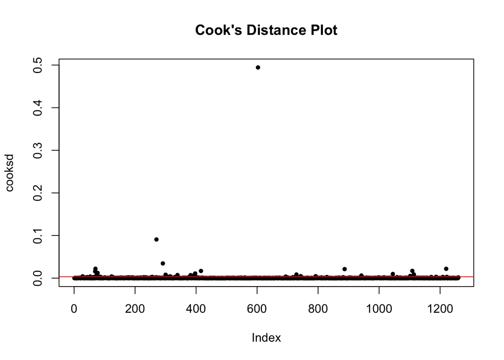

```r
cooksd <- cooks.distance(mod.all)
plot(cooksd, pch = 20, main = "Cook's Distance Plot")
abline(h = 4/length(cooksd), col = "red")
```

```r
outliers <- order(cooksd, decreasing = TRUE)[1:3]
outliers
```

```
## [1] 603 270 291
```

Residual Analysis

```r
beauty_clean <- beauty[-outliers,]
res_clean <- lm(wage ~. -expersq -lwage -looks_1 -looks_2 -looks_3 -looks_4 -looks_5, data = beauty_clean)
summary(res_clean)
```

```
##
## Call:
## lm(formula = wage ~ . - expersq - lwage - looks_1 - looks_2 -
##     looks_3 - looks_4 - looks_5, data = beauty_clean)
##
## Residuals:
##    Min     1Q Median     3Q    Max
## -6.614 -1.942 -0.465  1.230 30.549
##
## Coefficients:
##              Estimate Std. Error t value Pr(>|t|)
## (Intercept) -1.160152   0.702347  -1.652  0.09882 .
## belavg1     -0.802836   0.303331  -2.647  0.00823 **
## abvavg1     -0.123514   0.220067  -0.561  0.57472
## exper        0.082477   0.008766   9.408  < 2e-16 ***
## union1       0.419666   0.220141   1.906  0.05684 .
## goodhlth1    0.668170   0.395196   1.691  0.09114 .
## black1      -0.867813   0.380570  -2.280  0.02276 *
## female1     -2.184820   0.227001  -9.625  < 2e-16 ***
## married1     0.521271   0.225529   2.311  0.02098 *
## south1       0.515376   0.256126   2.012  0.04442 *
## bigcity1     1.452681   0.276402   5.256 1.73e-07 ***
## smllcity1    0.413818   0.225407   1.836  0.06662 .
## service1    -0.636935   0.236785  -2.690  0.00724 **
## educ         0.421210   0.041083  10.253  < 2e-16 ***
## ---
## Signif. codes:  0 '***' 0.001 '**' 0.01 '*' 0.05 '.' 0.1 ' ' 1
##
## Residual standard error: 3.394 on 1243 degrees of freedom
## Multiple R-squared:  0.2969, Adjusted R-squared:  0.2895
## F-statistic: 40.38 on 13 and 1243 DF,  p-value: < 2.2e-16
```

```r
summary(cooksd)
```

```
##      Min.   1st Qu.    Median      Mean   3rd Qu.      Max.
## 0.0000000 0.0000257 0.0001185 0.0009785 0.0003762 0.4943687
```

```r
beauty_clean <- beauty[cooksd < 0.0003762, ]
model.new <- lm(wage ~. -expersq -lwage -looks_1 -looks_2 -looks_3 -looks_4 -looks_5, data = beauty_clean)
summary(model.new)
```

```
##
## Call:
## lm(formula = wage ~ . - expersq - lwage - looks_1 - looks_2 -
##     looks_3 - looks_4 - looks_5, data = beauty_clean)
##
## Residuals:
##     Min      1Q  Median      3Q     Max
## -3.5221 -1.1430 -0.1272  1.0457  5.1643
##
## Coefficients:
##              Estimate Std. Error t value Pr(>|t|)
## (Intercept) -1.405644   0.405761  -3.464 0.000556 ***
## belavg1     -0.600605   0.157362  -3.817 0.000144 ***
## abvavg1      0.146868   0.115066   1.276 0.202140
## exper        0.083569   0.004865  17.177  < 2e-16 ***
## union1       0.939246   0.115290   8.147 1.20e-15 ***
## goodhlth1    0.386291   0.252469   1.530 0.126343
## black1      -0.028699   0.235632  -0.122 0.903086
## female1     -1.861660   0.117074 -15.902  < 2e-16 ***
## married1     0.387701   0.116498   3.328 0.000909 ***
## south1       0.217283   0.140874   1.542 0.123320
## bigcity1     1.532425   0.150127  10.208  < 2e-16 ***
## smllcity1    0.614330   0.115637   5.313 1.35e-07 ***
## service1    -0.399684   0.126266  -3.165 0.001599 **
## educ         0.396386   0.022763  17.414  < 2e-16 ***
## ---
## Signif. codes:  0 '***' 0.001 '**' 0.01 '*' 0.05 '.' 0.1 ' ' 1
##
## Residual standard error: 1.53 on 930 degrees of freedom
## Multiple R-squared:  0.624,  Adjusted R-squared:  0.6188
## F-statistic: 118.7 on 13 and 930 DF,  p-value: < 2.2e-16
```